# **MOZAMBIQUE COVID-19 DISEASE RESPONSE**

B.P.U.Wijethunga

10/6/2022

```
function ()
.Internal(getwd())
<bytecode: 0x0000000016ec7cb0>
<environment: namespace:base>
```

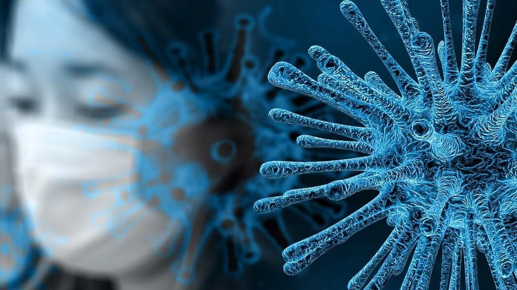

## **1.Introduction**

WHO declared COVID-19 as a pandemic on 13 March 2020. On 22 March 2020, the Government of Mozambique officially declared the first COVID-19 case; despite extensive preventative measures additional cases have steadily been identified. Concern about the potential spread of COVID-19 in Mozambique was elevated in late March, when according to Mozambique’s National Migration Service (SENAMI) over 14,000 Mozambican migrants returned from South Africa over the Ressano Garcia border, within a span of a few days, as South Africa declared lock-down due to COVID-19. While screening and contact tracing has been widely carried out, the number of cases in Mozambique passed 100 on 11 May; and as of 26 May, 213 cases of COVID-19 have been identified. While cases were initially clustered in Maputo and Palma areas, new cases have been registered across almost all of Mozambique’s 11 provinces. Mozambique is on Level 3 Alert since 1 April, including restrictions on gatherings, commercial activity and closure of many border points. Some neighbouring countries have higher COVID-19 cumulative case numbers: over 23,000 in South Africa, over 500 in Tanzania, and over 900 in Zambia, which raises concern near border areas.

IOM aims to contribute to the Government of Mozambique and partners’ preparedness and response efforts for COVID -19 to reduce transmission, associated morbidity and mortality and mitigate the impact of the outbreak. IOM recognizes that preparedness and response plans need to be responsive to population mobility and crossborder dynamics, and that inclusive approaches which take into account migrants, travellers, displaced populations, and local communities are essential in the event of an outbreak. Efforts are initially focused on preparedness and response, but IOM is responding to the need for mitigating the socioeconomic impact of the pandemic by incorporating elements of social cohesion programming throughout. IOM supports the Government of Mozambique’s COVID-19 response in the areas of coordination, infection prevention and control, risk communication and community engagement, disease surveillance, points of entry, case management and continuity of essential services. Activities are in line with national and WHO recommendations, the Global HRP, the IASC Interim Guidance on COVID-19, and IOM COVID-19 Global Preparedness and Response Plan.

### **Visualisation of the location**

```
function ()
.Internal(getwd())
<bytecode: 0x0000000016ec7cb0>
<environment: namespace:base>
```

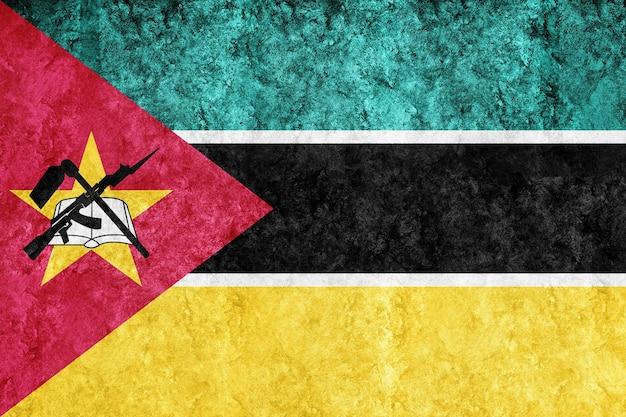

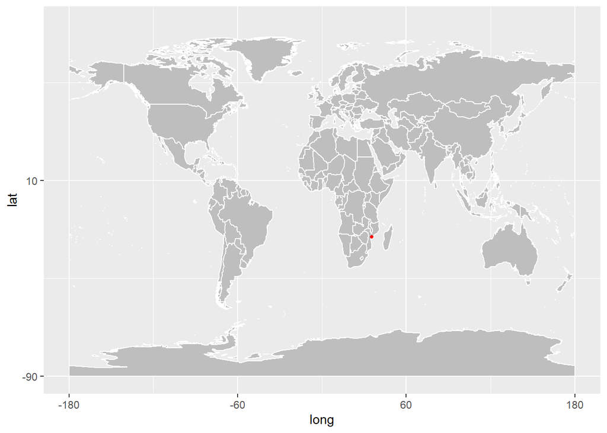

### **Weather and Climate**

The climate in most of Mozambique is tropical and warm with a dry, cooler season from May until October and a wet, hot season from November until April. The Dry season corresponds with winter and the Wet season with summer (at the opposite time of winter and summer in Europe and North America). Aside from January and February, which tend to be very wet, the beaches are lovely throughout the year.

Inhambane is a coastal town located in the south of Mozambique. Its warm sub-tropical climate is representative of most of the country. Like Inhambane, the whole coast has some rain throughout the year, although much more in the Wet season, from November to April. Parks in the interior, such as Niassa and Limpopo, tend to be totally dry during the Dry season, from May to October. It is hotter and more humid on the north coast of the country than in the south. Rainfall in Gorongosa NP is higher than in Inhambane.

### **Geography of Mozambique**

Geographically, Mozambique covers an area of over 800,000 sq. km, three times the size of Great Britain. Situated to the south east of the African continent, it shares borders with six other countries, Tanzania, Malawi and Zambia to the north, Zimbabwe to the west, South Africa and Swaziland to the south. The 2,500 km long coastline boasts numerous superb beaches fringed by lagoons, coral reefs and strings of small islands.

The Geography of Mozambique apprises a vast, low, grassland plateau which rises from the coast towards the mountains in the north and west covers nearly half the country’s land area. The population is concentrated along the coast and the fertile river valleys. The Zambezi is the largest of the country’s 25 rivers. Mozambique is rich in mineral resources such as gold, emeralds, copper, iron ore and bauxite and is currently engaged in oil exploration.

### **Lockdown status of Mozambique**

No travel is risk-free during COVID-19. Countries may further restrict travel or bring in new rules at short notice, for example due to a new COVID-19 variant. Check with your travel company or airline for any transport changes which may delay your journey home.

Plan ahead and make sure you:

can access money understand what your insurance will cover can make arrangements to extend your stay and be away for longer than planned If you test positive for COVID-19 whilst in Mozambique, you must self-isolate in a hotel or private accommodation. If you do not have symptoms, you must self-isolate until advised otherwise by their doctor, after testing negative, or for 7 days. If you test positive and are showing symptoms, you must self-isolate for 7 days after developing symptoms.

If you are forced to self-isolate, please make sure you have a plan for ensuring continued access to supplies such as food, as there is no government provision.

These measures are the same for all ages.

If you think you have COVID-19 symptoms, you should contact the Mozambique National Institute of Health on 82 34 34/ 84 34 34 /86 34 34 000 and follow their instructions. You can also reach out to health assistance through the following routes:

Dial free line Alo Vida (Hello Life): 1490 through TmCel and Movitel networks Dial free line Alo Vida 84146 if calling from a Vodacom network Reach out to PENSA (Think) through *660# Reach out via WhatsApp Fica Atento (stay alert) through +258 843318727 Visit the Mozambican government’s COVID-19 website for more information (This website is only available in Portuguese)

## **2.Data Exploratory**

```
function ()
.Internal(getwd())
<bytecode: 0x0000000016ec7cb0>
<environment: namespace:base>
```

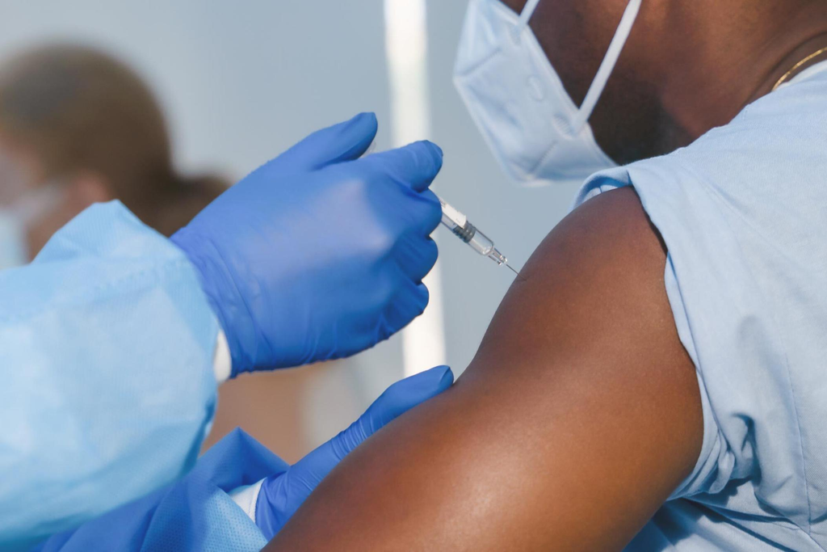

```
      date              province           country               lat
 Min.   :2020-01-22   Length:884         Length:884         Min.   :-18.67
 1st Qu.:2020-08-29   Class :character   Class :character   1st Qu.:-18.67
 Median :2021-04-07   Mode  :character   Mode  :character   Median :-18.67
 Mean   :2021-04-07                                         Mean   :-18.67
 3rd Qu.:2021-11-14                                         3rd Qu.:-18.67
 Max.   :2022-06-23                                         Max.   :-18.67
      long           type               cases             uid
 Min.   :35.53   Length:884         Min.   : -16.0   Min.   :508
 1st Qu.:35.53   Class :character   1st Qu.:   8.0   1st Qu.:508
 Median :35.53   Mode  :character   Median :  54.0   Median :508
 Mean   :35.53                      Mean   : 257.3   Mean   :508
 3rd Qu.:35.53                      3rd Qu.: 181.5   3rd Qu.:508
 Max.   :35.53                      Max.   :4947.0   Max.   :508
     iso2               iso3               code3     combined_key
 Length:884         Length:884         Min.   :508   Length:884
 Class :character   Class :character   1st Qu.:508   Class :character
 Mode  :character   Mode  :character   Median :508   Mode  :character
                                       Mean   :508
                                       3rd Qu.:508
                                       Max.   :508
   population       continent_name     continent_code
 Min.   :31255435   Length:884         Length:884
 1st Qu.:31255435   Class :character   Class :character
 Median :31255435   Mode  :character   Mode  :character
 Mean   :31255435
 3rd Qu.:31255435
 Max.   :31255435
```

### **Visualization of corona virus cases in Mozambique**

### Visualization of COVID-19 confirmed cases in Mozambique

Represents the confirmed coronavirus cases in Mozambique.

```
        date province    country       lat     long      type cases uid iso2
1 2020-01-22     <NA> Mozambique -18.66569 35.52956 confirmed     0 508   MZ
2 2020-01-23     <NA> Mozambique -18.66569 35.52956 confirmed     0 508   MZ
3 2020-01-24     <NA> Mozambique -18.66569 35.52956 confirmed     0 508   MZ
4 2020-01-25     <NA> Mozambique -18.66569 35.52956 confirmed     0 508   MZ
5 2020-01-26     <NA> Mozambique -18.66569 35.52956 confirmed     0 508   MZ
6 2020-01-27     <NA> Mozambique -18.66569 35.52956 confirmed     0 508   MZ
  iso3 code3 combined_key population continent_name continent_code
1  MOZ   508   Mozambique   31255435         Africa             AF
2  MOZ   508   Mozambique   31255435         Africa             AF
3  MOZ   508   Mozambique   31255435         Africa             AF
4  MOZ   508   Mozambique   31255435         Africa             AF
5  MOZ   508   Mozambique   31255435         Africa             AF
6  MOZ   508   Mozambique   31255435         Africa             AF
```

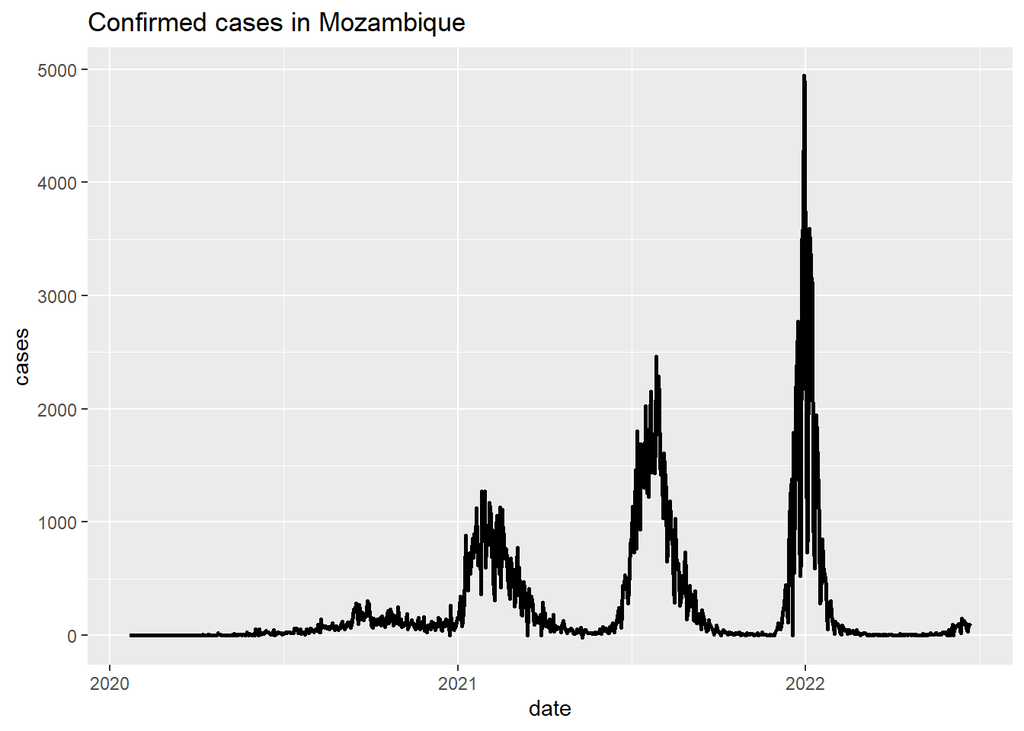

Above graph showas the confirmed no.of corona patients in Mozambique in daily basis.

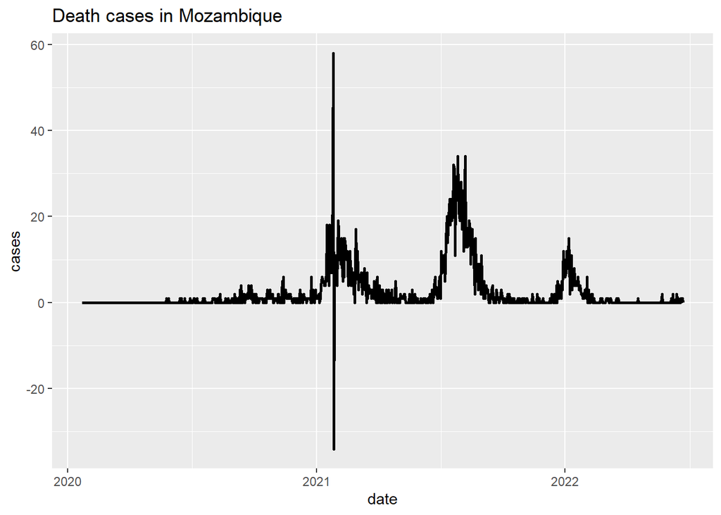

Above graph shows the no.of deadth from Corona in Mozambique in daily basis.

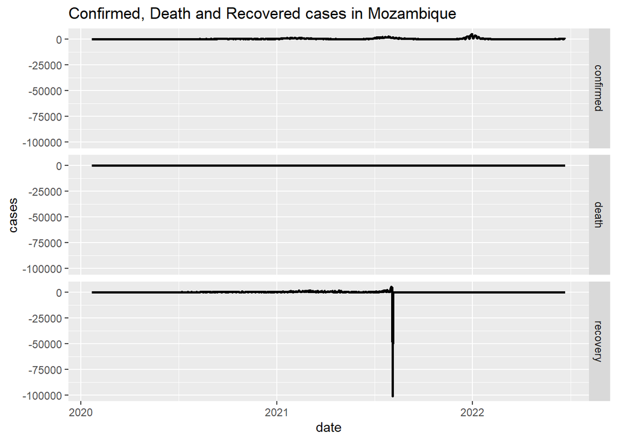

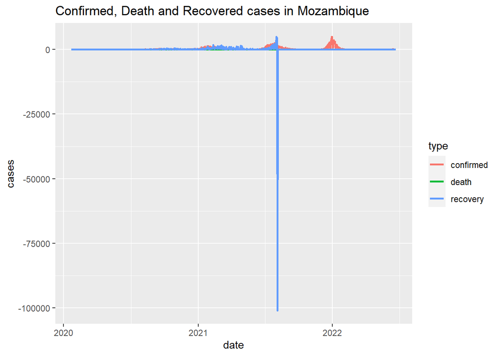

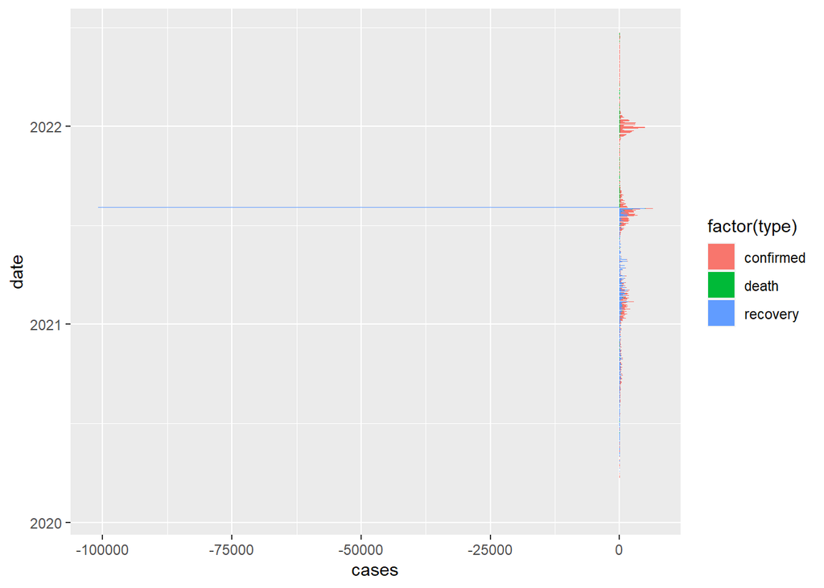

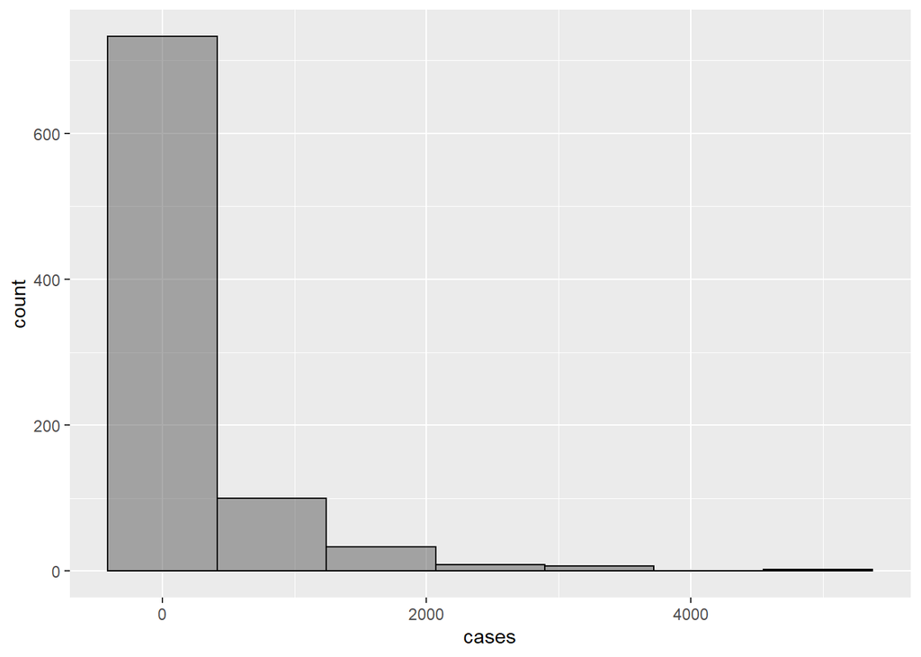

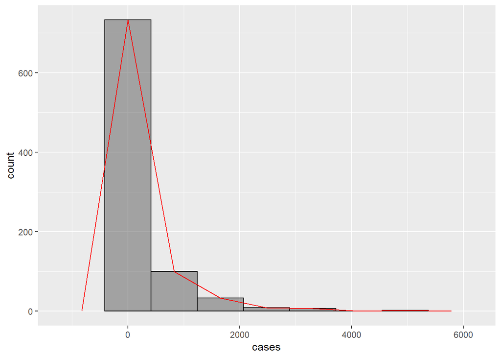

[figure not shown]

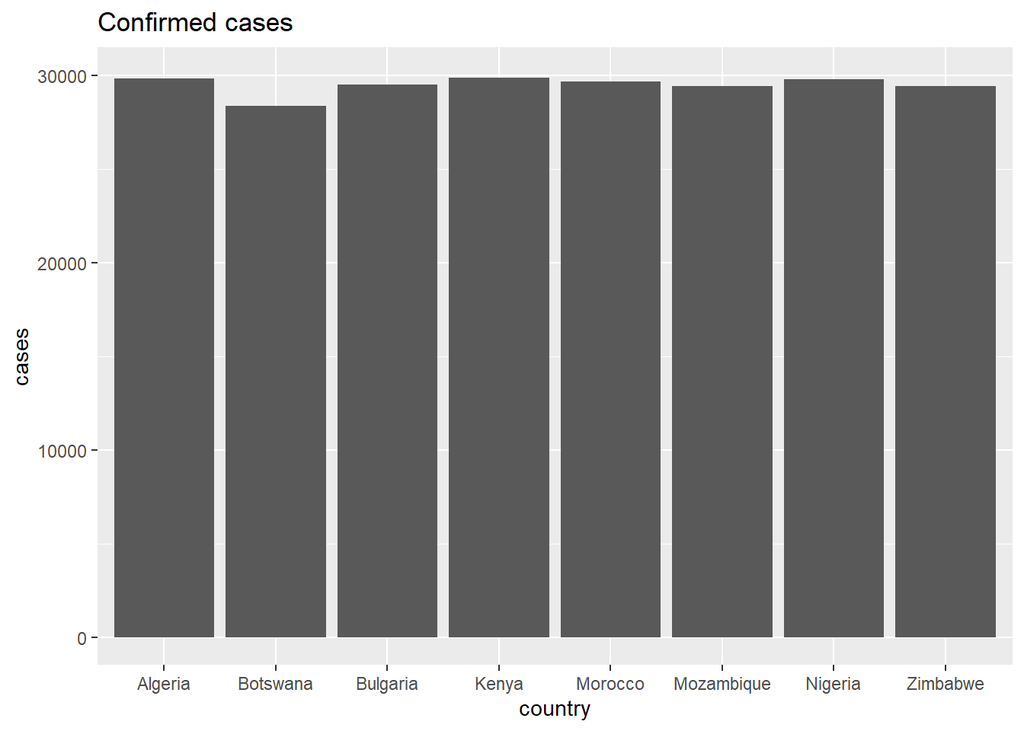

[figure not shown]